# Class 10: Politically Violent Activity

Local support and public reaction

[Dr. Michael C. Zeller](https://michaelzeller.de)

# Opening notes

[Open Sticker](https://tenor.com/view/open-gif-14209777)from [Open Stickers](https://tenor.com/search/open-stickers)

## Presentation groups

Presentations line-up

| Date | Presenters | Method |
| --- | --- | --- |
| 4 Dec: | Shahadaan, Kristine, Daichi | ethnography |
| 11 Dec: | Bérénice, Zorka, Victoria, Katharina | content analysis |
| 18 Dec: | Shoam, Aidan, Tara, Sebastian | QCA |

# Support in an armed conflict setting

- Meier (2022)
  - Tamils in Sri Lanka
  - territory
  - three patterns

[Intractable Conflict Hugh Grant GIF](https://tenor.com/view/intractable-conflict-hugh-grant-tennyson-foss-death-to2020-hard-to-control-gif-19844587)from [Intractable Conflict GIFs](https://tenor.com/search/intractable+conflict-gifs)

## Sri Lanka map

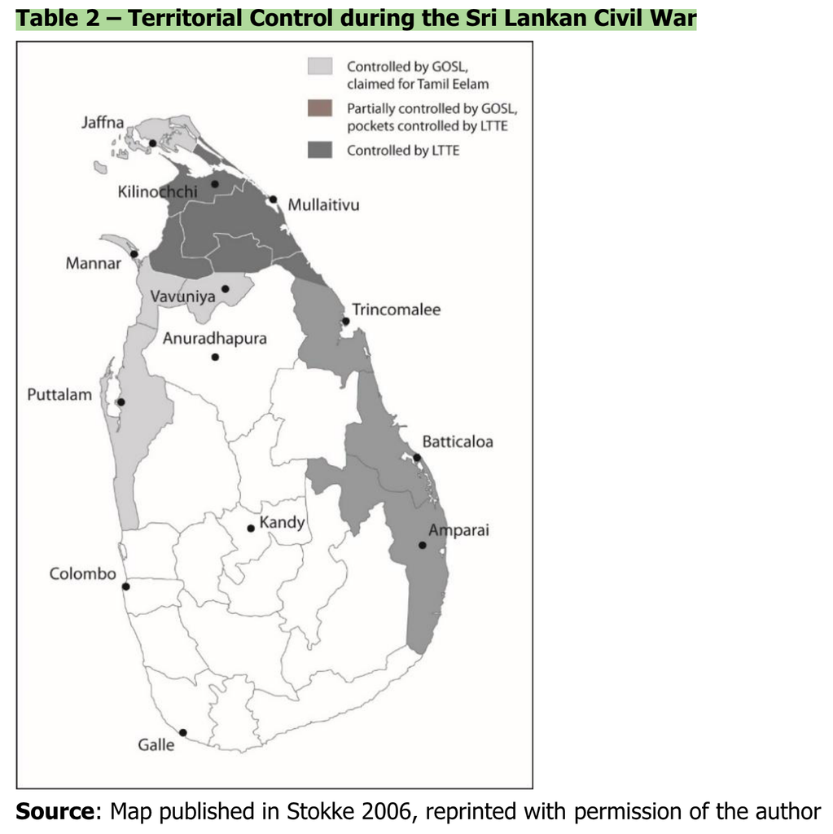

## Meier (2022) - 3 patterns

1. political representation and social distance; (2) fear and the relevance of affective ties; (3) security and (forceful) recruitment.

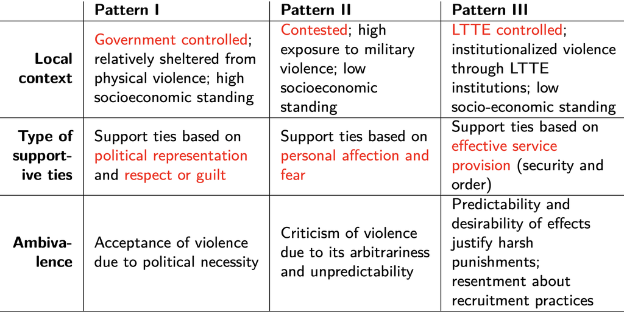

## Meier (2022) - 3 patterns

- respondents in LTTE territory, interacting with LTTE’s political and administrative institutions, more likely to support LTTE, having experienced them as service providers rather than as armed attackers.
- LTTE support not “solely coerced or entirely free of force”
- (p. 171) “it is more fruitful to explore how civilians cope with and react to this ambivalence. As the empirical evidence has demonstrated, depending on the type of force and the group targeted, violence was perceived as more or less justified.”

# Poll: local support and public reaction

[figure not shown]

Take the survey at **https://forms.gle/VZJuzHbzXXtNW2KN9**

- local support necessary violent group to have success?
- violent escalation alienates public, reducing support?
- reason people support politically violent groups?
- citizens react differently to political violence depending on the the ideological motivations underlying the violence.
- when states respond repressively, it usually strengthens politically violent groups’ legitimacy?
- After an attack, demand for punishment rises. Should policymakers shift toward harsher policies?

Questions about groups: (1) Does the group try to grow its popular support? (2) Does the group’s violence increase local support for it? (3) What type of participation does the group most rely on? (4) Do most civilians in areas where the group is active support the group? (5) Does the group provide services (security, justice, welfare) that generate legitimacy?

[interactive chart not shown]

group tries to grow its popular support?

[interactive chart not shown]

group’s violence increases local support?

[interactive chart not shown]

## Group responses - type of participation

What type of participation does the group most rely on?

[interactive chart not shown]

## Group responses - civilian support

Do civilians where the group is active support the group?

[interactive chart not shown]

## Group responses - service provisions

Does the group provide services (security, justice, welfare) that generate legitimacy?

[interactive chart not shown]

## A recent controversy

[figure not shown]

In October 2023, the Irish Women’s Football team qualified for the Women’s World Cup. In the days after, the Irish public was ablaze with debate, politicians took turns condemning and defending the players, and UEFA launched an investigation that ended in a 20,000 EUR fine. Why? For singing a certain song…

## A recent controversy

[video not shown]

see also 8-minute roundtable: https://www.youtube.com/watch?v=KkGfRbh2_Vw

## Poll results

local support necessary violent group to have success?

[interactive chart not shown]

**Why do you think so? What might ‘success’ mean and does that affect the ‘necessity’ of local support?**

## Poll results: escalation and support

violent escalation tends to alienate the public, reducing support?

[interactive chart not shown]

most common reason people support politically violent groups?

[interactive chart not shown]

## Poll results: reaction and repression

different reaction depending on ideological motivation of violence?

[interactive chart not shown]

After an attack, following demand, should policymakers shift toward harsher policies?

[interactive chart not shown]

state repression usually strengthens violent groups’ legitimacy?

[interactive chart not shown]

# Public opinion on political violence

- Setter and Nepstad (2022)
  - background
  - research design
  - mechanisms
  - findings
- Völker (2023)
  - concepts
  - visibility, resonance, legitimacy
  - influential actors

[Public Opinion Meme GIF](https://tenor.com/view/public-opinion-meme-news-journalism-indoctrination-gif-21779558)from [Public Opinion GIFs](https://tenor.com/search/public+opinion-gifs)

## background on the George Floyd protests - Setter and Nepstad (2022)

- what are the most important points to know from this **context** and **catalysing event**?
- what factors might *escalate* activism to political violence? what factors might *restrain*?

## refresher: logics of restraint/escalation

restraint

1. A **strategic logic** (violence is counterproductive in the present circumstances)
2. A **moral logic** (certain forms of violence are illegitimate)
3. A **logic of ego maintenance** (we are not a violent organization)
4. A **logic of outgroup definition** (softening views on putative outgroups)
5. An **organisational logic** (the organisation evolves in ways that undermine the logics of violent escalation)

escalation

1. **framing logic** (intensity of context/threat, revolutionary goals, glorification of violence, violence as viable/necessary, increasing vilification of ‘enemies’)
2. **strategic logic** (cope with changing dynamics with opponents and/or state, deal with diminishing opportunity, loss of state control)
3. **organisational logic** (declining moderate influence, logistical/practical preparation for violence)
4. **constituency/social logic** (endorsement/legitimation from elites and/or public, politics/media focuses on radical flank)

## Setter and Nepstad (2022) - design

- RQ: *When such events happen, how does this shape citizens’ views on politically-oriented violence?*
- Context:
  - ‘U.S. citizens expect protesters to conduct themselves nonviolently…’ (p. 430)
  - YET - “people find violence more acceptable when traditional political methods are incapable of adequately addressing social injustices”
- Data:
  - from the **American National Election Study’s (ANES)** 2016 and 2020 samples

## how SMs influence public opinion - Setter and Nepstad (2022)

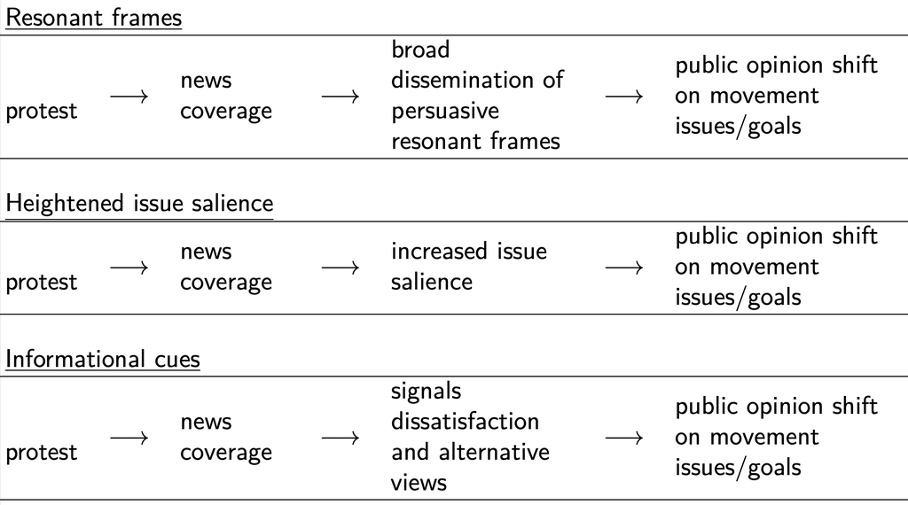

## support for political violence (%) - (2022)

| Demographic | 2016 | 2020 |
| --- | --- | --- |
| Sample Overall | 15.28 | 14.34 |
| Extremely Liberal | 14.55 | 30.79 |
| Liberal | 10.02 | 17.36 |
| Slightly Liberal | 16.83 | 16.23 |
| Moderate | 15.93 | 16.30 |
| Slightly Conservative | 14.84 | 8.59 |
| Conservative | 9.24 | 5.45 |
| Extremely Conservative | 12.71 | 8.22 |
| White | 11.79 | 10.89 |
| Black | 24.37 | 24.41 |
| Men | 16.45 | 14.13 |
| Women | 14.17 | 14.63 |
| Age 18-29 | 28.40 | 30.42 |
| Age 30-39 | 16.42 | 21.13 |
| Age 40-49 | 14.54 | 16.85 |
| Age 50-59 | 13.12 | 10.76 |
| Age 60-69 | 9.86 | 7.15 |
| Age 70-79 | 9.35 | 7.57 |
| Age 80+ | 15.03 | 6.02 |
| Attends Church | 16.10 | 12.82 |
| Does Not Attend Church | 14.00 | 15.81 |

any numbers that you think are noteworthy?

## support for political violence (%) - (2022)

| Demographic | 2016 | 2020 |
| --- | --- | --- |
| Sample Overall | 15.28 | 14.34 |
| Extremely Liberal | 14.55 | 30.79 |
| Liberal | 10.02 | 17.36 |
| Slightly Liberal | 16.83 | 16.23 |
| Moderate | 15.93 | 16.30 |
| Slightly Conservative | 14.84 | 8.59 |
| Conservative | 9.24 | 5.45 |
| Extremely Conservative | 12.71 | 8.22 |
| White | 11.79 | 10.89 |
| Black | 24.37 | 24.41 |
| Men | 16.45 | 14.13 |
| Women | 14.17 | 14.63 |
| Age 18-29 | 28.40 | 30.42 |
| Age 30-39 | 16.42 | 21.13 |
| Age 40-49 | 14.54 | 16.85 |
| Age 50-59 | 13.12 | 10.76 |
| Age 60-69 | 9.86 | 7.15 |
| Age 70-79 | 9.35 | 7.57 |
| Age 80+ | 15.03 | 6.02 |
| Attends Church | 16.10 | 12.82 |
| Does Not Attend Church | 14.00 | 15.81 |

- “liberals became much more likely to find political violence acceptable … conservatives became much less likely to find themselves in support of violence…”
- “Younger respondents were more likely to support political violence in 2020 … while their older counterparts were more opposed than before”

## support for political violence (%) - (2022)

| Demographic | 2016 | 2020 |
| --- | --- | --- |
| Sample Overall | 15.28 | 14.34 |
| Extremely Liberal | 14.55 | 30.79 |
| Liberal | 10.02 | 17.36 |
| Slightly Liberal | 16.83 | 16.23 |
| Moderate | 15.93 | 16.30 |
| Slightly Conservative | 14.84 | 8.59 |
| Conservative | 9.24 | 5.45 |
| Extremely Conservative | 12.71 | 8.22 |
| White | 11.79 | 10.89 |
| Black | 24.37 | 24.41 |
| Men | 16.45 | 14.13 |
| Women | 14.17 | 14.63 |
| Age 18-29 | 28.40 | 30.42 |
| Age 30-39 | 16.42 | 21.13 |
| Age 40-49 | 14.54 | 16.85 |
| Age 50-59 | 13.12 | 10.76 |
| Age 60-69 | 9.86 | 7.15 |
| Age 70-79 | 9.35 | 7.57 |
| Age 80+ | 15.03 | 6.02 |
| Attends Church | 16.10 | 12.82 |
| Does Not Attend Church | 14.00 | 15.81 |

> One strange outlier is the 2016 survey’s proportion of 80+ year-olds who find political violence acceptable. We have checked the coding on this variable multiple times to ensure that there is nothing wrong with it, and it has remained accurate every time. Either the 2016 ANES just happened to capture a particularly rowdy set of senior citizens, or there was some cohort effect among that sample’s oldest respondents that was not shared among the 2020 cohort—such as lingering memories of WWII or the 1960s movements.

## Setter and Nepstad (2022) - findings

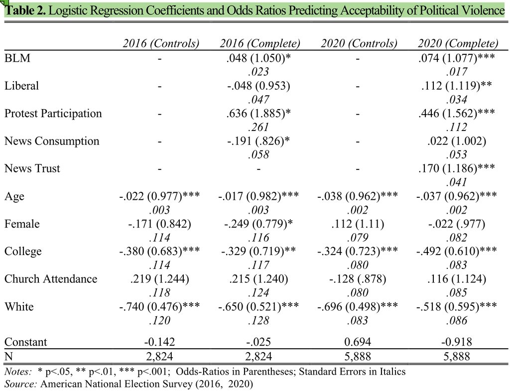

## Setter and Nepstad (2022) - findings

- support for Black Lives Matter is significantly correlated with support for political violence.
- “The impact of age intensified between 2016 and 2020. In the 2016 model, each additional year of age corresponds to a .2% lower likelihood of supporting political violence. In 2020, each additional year corresponds to a decrease of .4%, two times the impact of the previous model. In other words, in 2016, a fifty-year-old respondent would be 6% less likely to support political violence than a twenty-year-old respondent, net of all other factors. In 2020, by contrast, they would be 12% less likely to support political violence, net of all other factors.”
- significance of higher education: having a college degree decreases support for political violence by 3.4%.

## Setter and Nepstad (2022) - findings, revised model

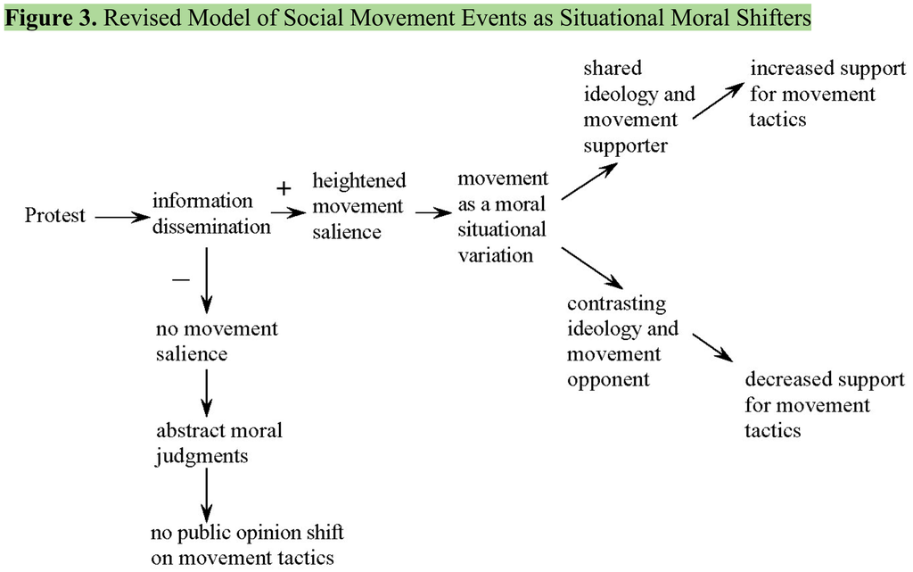

## Setter and Nepstad (2022) - findings

> the George Floyd riots functioned as a new “**situational variation**” that shifted people’s attitudes, increasing the proportion of liberals and ardent BLM movement supporters who felt that the political violence was justifiable.”
- “**people may shift their attitudes about political violence yet again when a different movement poses a new situational variation. In one instance, people can be supportive of political violence and then, in a different instance, be morally opposed to it. The key factor shaping beliefs in any particular moment is how a person feels about the movement that is using political violence.**”
- What do we take from these findings? How does local support (or opposition) manifest cases you know of?

## terrorist attacks and public debate - Völker (2023) RQs

> to what extent and how do terrorist attacks influence public debates? What are the differences between public debates after extreme right and Islamist terrorist attacks?

What do you expect, hypothesise?

[figure not shown]

## Völker (2023) - key concepts (1)

- **Discursive opportunity structures** - pre-existing values and visions around issues in the broader political culture of a country (Koopmans and Olzak 2004)
  - *issue-specific* discursive opportunity structures determine which actors and issues gain access to and influence public debates (Völker 2023, 2)
- **discursive critical junctures** - moments that intensify polarisation and transform existing political alignments and visions around issues
  - **can you think of an example?**

## Völker (2023) - key concepts (2)

Author’s own **discursive radicalisation model** - how radical actors may shape public debates after critical events such as terrorist attacks

1. *visibility* - how much do events/actors attract attention
2. *resonance* - political reactions that radical actors and events provoke and how they shape discourse dynamics on contested issues
3. *legitimacy* - extent to which actors and issues resonate positively and gain support

## Völker (2023) - research design

- data: mass media coverage after (for two weeks) all seven fatal politically violent attacks since 2015 (four by extreme right, three by Islamist)
  - 2016 in München, 2019 Walter Lübcke, 2019 Halle, 2020 Hanau; 2016 in Berlin, 2017 in Hamburg, 2020 in Dresden
- methods: relational quantitative content analysis, frame analysis, network analysis
  - *diagnostic* and *prognostic* frames
  - data and methods transparency! see online article: https://doi.org/10.1080/13501763.2023.2269194

## Visibility

Finding: the most publicised terrorist attacks were those where the debate centred on the ideological motives of the perpetrators and the political consequences of the act

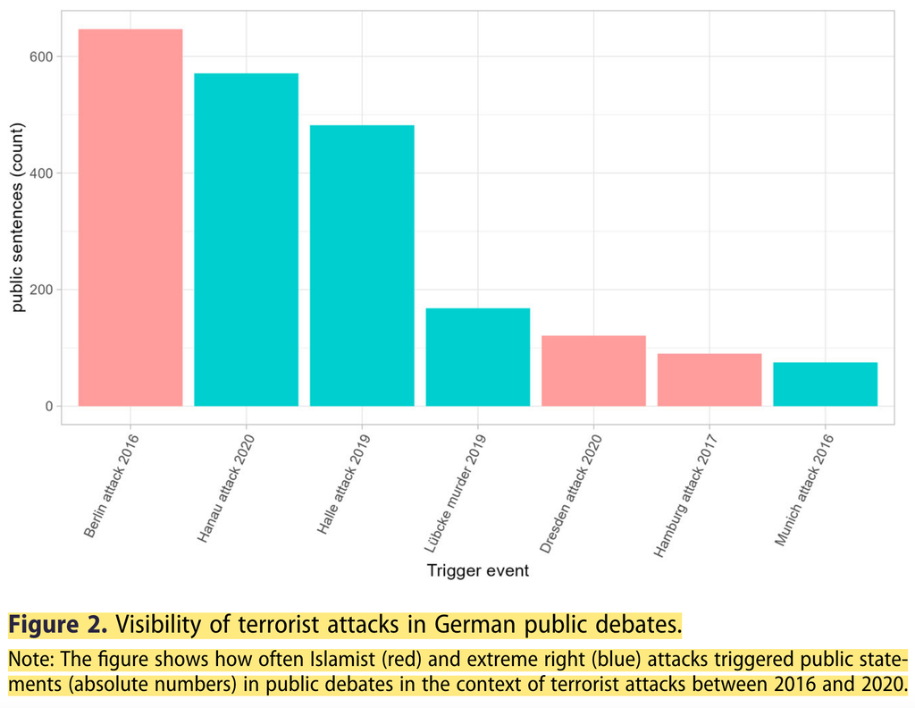

## Visibility

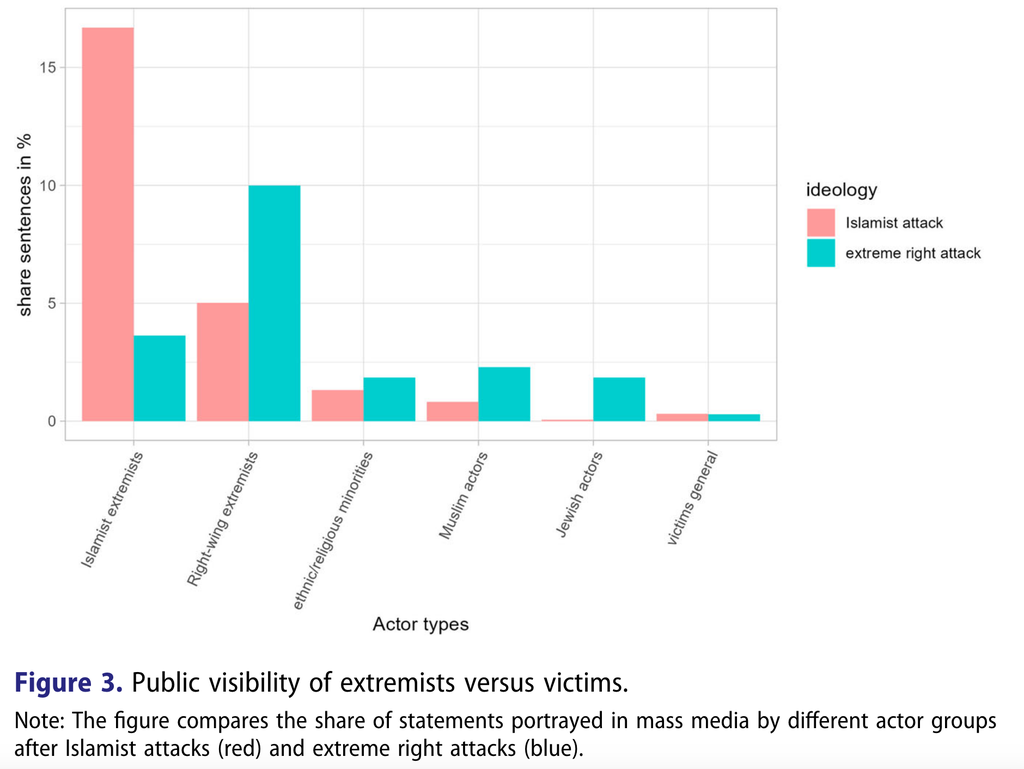

Finding: extremists (esp. Islamists) gain more discursive space after attacks

## Resonance

- “politicians from right-wing parties were more visible than politicians from left-wing parties in political debates after extreme right and Islamist attacks”
  - Right-wing parties were able to share their perspective as subjects in the debate in 59% of political statements after Islamist attack; 57% after extreme right attack
    - AfD politicians often the most visible actors
  - *why do you suppose this is the case?*
- “the content of public debates after terrorist attacks was related to the ideological motive behind the attack”
  - after Islamist attacks there is a *broad* debate about immigration and asylum
    - “debate evolved around the question of how and to what extent migration and Islam may be a breeding ground for radicalisation”
  - after extreme right attacks there is a *narrow* debate about RW extremism
    - “focus of the debate was on the perpetrator’s motives, individual radicalisation and right-wing extremism”

## Resonance

- “politicians from right-wing parties were more visible than politicians from left-wing parties in political debates after extreme right and Islamist attacks”
  - Right-wing parties were able to share their perspective as subjects in the debate in 59% of political statements after Islamist attack; 57% after extreme right attack
    - AfD politicians often the most visible actors
  - *why do you suppose this is the case?*
    - right-wing actors are successful issue entrepreneurs in moments of crisis (Della Porta et al., 2020, *Discursive turns and critical junctures: Debating citizenship after the Charlie Hebdo attacks*)
- “the content of public debates after terrorist attacks was related to the ideological motive behind the attack”
  - after Islamist attacks there is a *broad* debate about immigration and asylum
    - “debate evolved around the question of how and to what extent migration and Islam may be a breeding ground for radicalisation”
  - after extreme right attacks there is a *narrow* debate about RW extremism
    - “focus of the debate was on the perpetrator’s motives, individual radicalisation and right-wing extremism”

## Legitimacy

comparing level of public support for issues and actors as object of statements one week before and one week after Islamist and extreme right attacks: captures change of (average) positions on issues and actors as the objects of statements (-1 stands for a negative relationship and 1 for a positive relationship) covered in the mass media

|  | Public legitimacy shift (average position) Islamist attacks | Public legitimacy shift (average position) Extreme right attacks |
| --- | --- | --- |
| **Statements referring to Actors** |  |  |
| extreme right actors | -0.18 | -0.35 |
| Islamist actors | -0.28 | -0.37 |
| **Statements referring to Issues** |  |  |
| Islam | -0.35 | -0.11 |
| migration | -0.19 | -0.55 |
| nationalism | -0.19 | -0.16 |
| radicalisation | 0.01 | -0.06 |

## Legitimacy

|  | Public legitimacy shift (average position) Islamist attacks | Public legitimacy shift (average position) Extreme right attacks |
| --- | --- | --- |
| **Statements referring to Actors** |  |  |
| extreme right actors | -0.18 | -0.35 |
| Islamist actors | -0.28 | -0.37 |
| **Statements referring to Issues** |  |  |
| Islam | -0.35 | -0.11 |
| migration | -0.19 | -0.55 |
| nationalism | -0.19 | -0.16 |
| radicalisation | 0.01 | -0.06 |

Terrorist attacks reduce the public legitimacy of extremist actors and their political agenda in public debates

## Legitimacy

|  | Public legitimacy shift (average position) Islamist attacks | Public legitimacy shift (average position) Extreme right attacks |
| --- | --- | --- |
| **Statements referring to Actors** |  |  |
| extreme right actors | -0.18 | -0.35 |
| Islamist actors | -0.28 | -0.37 |
| **Statements referring to Issues** |  |  |
| Islam | -0.35 | -0.11 |
| migration | -0.19 | -0.55 |
| nationalism | -0.19 | -0.16 |
| radicalisation | 0.01 | -0.06 |

legitimacy of Islam decreases more after Islamist attacks than the legitimacy of nationalism does after extreme right attacks (*issues*)

## influential actors - Völker (2023)

Who were the most influential actors in pushing frames and issues onto the media agenda?

To answer this, Völker (2023) creates ‘discourse networks’

- the discourse networks have two types of **nodes**: *actors* and *issues*
- directed ties (**arrows**) show which issues actors focus on
  - **size** of the arrow represents number of statements
  - **color** of the arrow represents average position
    - **positive**
    - **negative**
    - **neutral**

## influential actors (after Islamist attacks)

- **nodes**: *actors* and *issues*
- directed ties (**arrows**) show which issues actors focus on
  - **size** of the arrow represents number of statements
  - **color** of the arrow represents average position
    - **positive**, **negative**, **neutral**

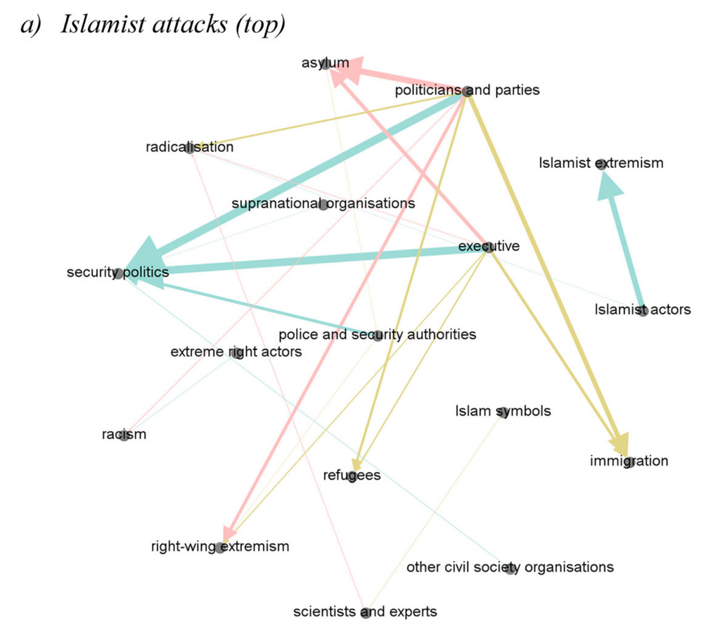

## influential actors (after extreme right attacks)

- **nodes**: *actors* and *issues*
- directed ties (**arrows**) show which issues actors focus on
  - **size** of the arrow represents number of statements
  - **color** of the arrow represents average position
    - **positive**, **negative**, **neutral**

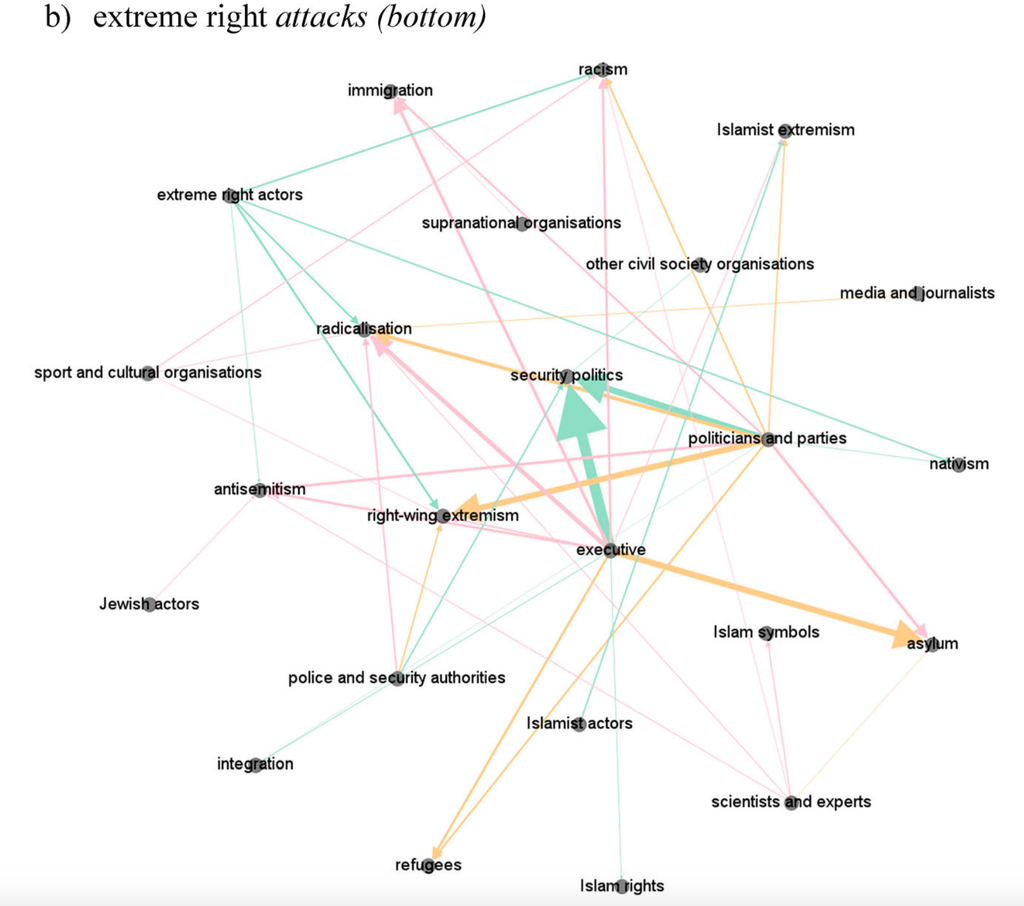

## Völker (2023) - findings

- similar actor constellations emerged and dominated public debates after terrorist attacks
  - **governmental actors** and **political parties** drive post-attack debates
  - emphasis is on **security policies** and **strengthening counter-terrorism** (‘securitisation’)

Public and political reactions drive state policy and repressive responses (covered in the next two weeks)

(*relates to repressive responses that we will address in Week 12*)

## next meeting

- state responses
- in the meantime…

*Io Saturnalia!* and happy holidays

# Any feedback for this class?

Anonymous feedback here: https://forms.gle/NfF1pCfYMbkAT3WP6

Alternatively, please send me an email: m.zeller@lmu.de

Questions about groups next meeting: (1) Are state responses primarily driven by security concerns (rather than political considerations)? (2) Does the state mostly use policy-based responses? (3) Does the state have a coherent long-term strategy toward the group? (4) How is the group categorised by the state? (5) Has the state engaged the group in negotiation? (6) Do foreign governments shape state responses toward the group?

## References

Koopmans, Ruud, and Susan Olzak. 2004. “Discursive Opportunities and the Evolution of Right-Wing Violence in Germany.” *American Journal of Sociology* 110 (1): 198–230. https://doi.org/10.1086/386271.

Meier, Larissa Daria. 2022. “Between Coercion and Representation: Exploring Variation in Support Relations Between Tamil Civilians and the Liberation Tigers of Tamil Eelam (LTTE).” *Partecipazione e Conflitto* 15 (1): 157–74.

Setter, Davyd, and Sharon Erickson Nepstad. 2022. “How Social Movements Influence Public Opinion on Political Violence: Attitude Shifts in the Wake of the George Floyd Protests.” *Mobilization: An International Quarterly* 27 (4): 429–44. https://doi.org/10.17813/1086-671X-27-4-429.

Völker, Teresa. 2023. “How Terrorist Attacks Distort Public Debates: A Comparative Study of Right-Wing and Islamist Extremism.” *Journal of European Public Policy*, October, 1–28. https://doi.org/10.1080/13501763.2023.2269194.